# Regression Analysis

7. Dummy Variable | Special Lecture for KINS

Boncho Ku, Ph.D. in Statistics

secondmoon@kiom.re.kr

Digital Health Research Division

Korea Institute of Oriental Medicine

2026-09-01

# Dummy Variable

## 질적 설명변수의 처리

### 복습: 변수의 유형

**앞 장에서 여기까지**: 관측별 신뢰도를 가중치로 반영. **이 장의 질문**: 숫자가 아닌 범주 정보를 설계행렬에 어떻게 넣는가

**Types of variables**

- 양적 변수(quantitative): 온도, 가격, 소득처럼 수치로 측정되어 크기와 간격이 정의되는 변수
- 질적 변수(qualitative): 관측 연차, 계측기 제조사, 운전/정지 상태, 제품 형태처럼 범주로만 구분되는 변수
- 회귀분석에서 **반응변수는 양적 변수**, **설명변수는 양적과 질적 모두 가능**

### 질문

질적 변수의 범주에는 덧셈과 곱셈이 정의되지 않는다. 이 정보를 어떻게 $\mathbf y=\mathbf X\boldsymbol\beta+\boldsymbol\varepsilon$의 설계행렬 $\mathbf X$의 열로 만들 것인가?

**기호**

- $\mathbf X$: 절편열을 포함한 $n\times(p+1)$ 설계행렬
- $n$: 관측 수, $p$: 설명변수의 개수
- $\mathbf X$ 의 원소는 모두 숫자여야 하므로 범주 이름을 그대로 넣을 수 없음

## 가변수의 정의

### 정의

**가변수(dummy variable, indicator variable)**: 질적 설명변수의 특정 범주에 대해
$$d_i=\begin{cases} 1, & i\text{번째 관측이 그 범주에 속할 때}\\\ 0, & \text{그 외}\end{cases}$$
로 정의되는 0/1 지시변수.

**기호**

- $d_i$: $i$번째 관측이 그 범주에 속하는지를 나타내는 값($i=1,\dots,n$)
- 값이 0 또는 1인 숫자이므로 설계행렬 $\mathbf X$ 의 한 열이 될 수 있음

### 핵심

- 범주 자체를 수치화하는 것이 아니라, **범주에 속하는지 여부**를 0과 1로 기록
- 가변수가 들어간 모형도 여전히 $\mathbf y=\mathbf X\boldsymbol\beta+\boldsymbol\varepsilon$ 형태의 선형모형. 추정과 검정 절차는 앞 장과 동일

## 예제 자료: 관측 연차

### 자료 구조

First 5 rows of the ice cream data. n = 30 four-week periods, 6 variables.

| period | IC | price | income | temp | year |
| --- | --- | --- | --- | --- | --- |
| 1 | 0.386 | 0.270 | 78 | 41 | 0 |
| 2 | 0.374 | 0.282 | 79 | 56 | 0 |
| 3 | 0.393 | 0.277 | 81 | 63 | 0 |
| 4 | 0.425 | 0.280 | 80 | 68 | 0 |
| 5 | 0.406 | 0.272 | 76 | 69 | 0 |

### 핵심

- `year`는 0/1/2 값을 가지는 **관측 연차**, 곧 몇 년째 기록인지를 나타내는 질적 변수. 계절 구분이 아님
- 앞 장까지는 `price`, `income`, `temp`만 사용하고 `year`는 보류
- `year`의 범주 수는 $k=3$

## 가변수 코딩: $k-1$개 규칙

### 코딩 규칙

Dummy coding for the observation year. k = 3 categories require only k - 1 = 2 indicator columns.

| year (observation year) | $d_{i1}$ | $d_{i2}$ |
| --- | --- | --- |
| 0 (baseline) | 0 | 0 |
| 1 | 1 | 0 |
| 2 | 0 | 1 |

**기호**

- $d_{i1}$: 관측 연차가 year = 1이면 1, 아니면 0인 가변수
- $d_{i2}$: 관측 연차가 year = 2이면 1, 아니면 0인 가변수

### 핵심

- 범주가 $k$개면 가변수는 $k-1$개. `year`는 $k=3$이므로 가변수 2개로 충분
- 모든 가변수가 0인 상태가 **기준 범주**(baseline, 여기서는 year = 0)이며, 그 수준은 절편 $\beta_0$ 가 담당

## 가변수 코딩: dummy trap

### $k$개 모두 넣은 경우

**유도**

범주 수만큼 가변수를 만들어 year = 0을 나타내는 $d_{i0}$까지 설계행렬에 넣으면, 모든 관측에서

$$d_{i0}+d_{i1}+d_{i2}=1,\qquad i=1,\dots,n$$

가 항상 성립

- $d_{i0}$: year = 0이면 1, 아니면 0인(실제로는 만들지 않는) 세 번째 가변수
- 우변의 1은 절편에 대응하는 열, 곧 모든 원소가 1인 $\mathbf X$ 의 첫 열과 동일
- 한 열이 다른 열들의 합으로 그대로 재현되므로 **완전 공선성**(설명변수 열 사이에 정확한 선형 관계가 성립하는 상태)이 발생
- 이때 $\mathbf X^\top\mathbf X$ 의 역행렬이 존재하지 않아 최소제곱해가 유일하게 결정되지 않으며, 이를 dummy trap이라 부름

### 해결: 기준범주의 흡수

$d_{i0}$ 을 만들지 않고 빼면 열 사이의 선형관계가 사라져 $\mathbf X^\top\mathbf X$ 의 역행렬이 존재

$$\mathbf X=\big[\;\underbrace{\mathbf 1}_{\text{절편}}\;\;\underbrace{\mathbf x}_{\text{temp}}\;\;\underbrace{\mathbf d_1\;\;\mathbf d_2}_{k-1=2\,\text{개}}\;\big]_{30\times 4},
\qquad \operatorname{rank}(\mathbf X)=4$$

빠진 범주 year = 0 은 사라진 것이 아니라 절편 $\beta_0$ 이 대신 나타냄. 그래서 이 범주를 **기준범주(baseline)** 라 부름

## 평행선 모형: 정의

### 기울기는 공통, 절편만 이동

$$y_i = \beta_0 + \beta_1 x_i + \beta_2 d_{i1} + \beta_3 d_{i2} + \varepsilon_i$$

**기호**

- $y_i$: $i$번째 기간의 아이스크림 소비량(IC), $x_i$: 온도(temp)
- $d_{i1}, d_{i2}$: 관측 연차가 각각 year = 1, year = 2일 때 1이 되는 가변수
- $\beta_0$: 기준 연차(year = 0)의 절편, $\beta_1$: 세 연차가 공유하는 온도의 기울기
- $\beta_2, \beta_3$: 기준 연차 대비 절편의 차이, $\varepsilon_i$: 평균 0, 분산 $\sigma^2$ 인 오차

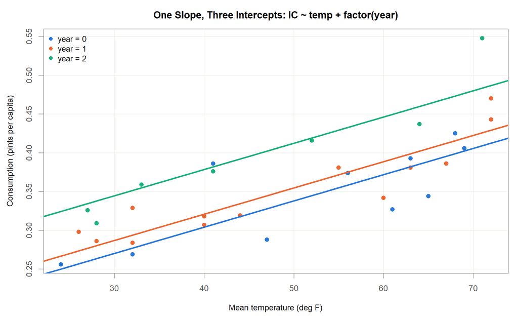

One common slope, three year-specific intercepts (parallel-lines model)

Kutner, Nachtsheim, Neter & Li (2005), *Applied Linear Statistical Models*, 5th ed., McGraw-Hill.

## 평행선 모형: 연차별 반응함수

### 조건부 기댓값 표현

회귀를 조건부 기댓값 $E(Y\mid X=x)$로 정의하였으므로, 가변수를 포함한 모형도 연차별 조건부 기댓값으로 읽는다.

$$\begin{aligned}
E(y_i \mid x_i,\ \text{year}=0) &= \beta_0 + \beta_1 x_i\\
E(y_i \mid x_i,\ \text{year}=1) &= (\beta_0+\beta_2) + \beta_1 x_i\\
E(y_i \mid x_i,\ \text{year}=2) &= (\beta_0+\beta_3) + \beta_1 x_i
\end{aligned}$$

### 핵심

- 연차별 절편: year = 0은 $\beta_0$, year = 1은 $\beta_0+\beta_2$, year = 2는 $\beta_0+\beta_3$
- 기울기 $\beta_1$ 은 세 연차가 공통이므로, 가변수는 직선을 **위아래로 평행이동**만 시킴
- $\beta_2$ = 온도를 같은 값으로 고정했을 때 year = 1과 year = 0의 평균 소비량 차이

## 평행선 모형: 적합 결과

### 추정한 모형

$$y_i=\beta_0+\beta_1 x_i+\beta_2 d_{i1}+\beta_3 d_{i2}+\varepsilon_i,\qquad i=1,\dots,30$$

**기호**

- $x_i$: temp
- $d_{i1}$: year = 1이면 1 아니면 0, $d_{i2}$: year = 2이면 1 아니면 0
- 추정할 계수는 네 개

### 결과

Coefficients of the parallel-lines model. R-squared = 0.790, adjusted R-squared = 0.765, n = 30.

| Term | Estimate | p-value |
| --- | --- | --- |
| $\hat\beta_0$ (intercept, year = 0) | 0.169 | n.a. |
| $\hat\beta_1$ (temp) | 0.00339 | 1.0e-09 |
| $\hat\beta_2$ ($d_1$: year = 1) | 0.0165 | 0.232 |
| $\hat\beta_3$ ($d_2$: year = 2) | 0.0743 | 8.2e-05 |

p-value = 해당 계수가 실제로는 0이라고 가정했을 때 지금 얻은 것만큼 큰 계수가 우연히 나올 확률. 작을수록 계수가 0이 아니라는 근거가 강함

## 평행선 모형: 결과 해석

### 연차 효과의 잔존

- 온도의 기울기 0.00339는 세 연차 공통. $p = 1.0\times10^{-9}$ 로 매우 유의
- 같은 온도에서 3년차(year = 2)의 평균 소비량은 1년차(year = 0)보다 **0.0743 높음** ($p = 8.2\times10^{-5}$)
- 2년차(year = 1)의 차이 0.0165는 $p = 0.232$. 1년차와 다르다고 보기 어려움
- 연차별 절편: year = 0은 $\hat\beta_0=0.169$, year = 1은 $\hat\beta_0+\hat\beta_2=0.185$, year = 2는 $\hat\beta_0+\hat\beta_3=0.243$
- 온도만 사용한 단순회귀의 $R^2 = 0.602$에서 가변수 추가 후 $R^2 = 0.790$으로 상승 (adj. $R^2 = 0.765$)

## 상호작용 모형: 도입

### 주의: 평행선 모형의 숨은 가정

평행선 모형은 관측 연차가 **절편만** 바꾼다고 가정한다. 온도에 대한 민감도, 즉 기울기는 세 연차가 동일하다고 강제한다.

### 상호작용 모형

$$y_i = \beta_0 + \beta_1 x_i + \beta_2 d_{i1} + \beta_3 d_{i2} + \beta_4 x_i d_{i1} + \beta_5 x_i d_{i2} + \varepsilon_i$$

**기호**

- $x_i d_{i1}$, $x_i d_{i2}$: 온도와 연차 가변수를 곱한 상호작용 항
- $\beta_4, \beta_5$: year = 1, year = 2에서 기울기가 기준 연차보다 달라지는 양
- 나머지 기호는 앞 슬라이드와 동일

## 상호작용 모형: 연차별 직선

### 가변수에 0과 1을 대입

가변수에 0과 1을 대입하면 연차별 회귀직선이 분리됨

$$\begin{aligned}
\text{year}=0:\quad & y_i = \beta_0 + \beta_1 x_i + \varepsilon_i\\
\text{year}=1:\quad & y_i = (\beta_0+\beta_2) + (\beta_1+\beta_4) x_i + \varepsilon_i\\
\text{year}=2:\quad & y_i = (\beta_0+\beta_3) + (\beta_1+\beta_5) x_i + \varepsilon_i
\end{aligned}$$

year = 1의 기울기는 $\beta_1+\beta_4$. 절편뿐 아니라 기울기까지 연차별로 달라지므로 세 직선은 더 이상 평행하지 않음

### 상호작용항을 포함한 모형식

$$y_i=\beta_0+\beta_1 x_i+\beta_2 d_{i1}+\beta_3 d_{i2}
+\beta_4\,(x_i d_{i1})+\beta_5\,(x_i d_{i2})+\varepsilon_i$$

**기호**

- $x_i d_{i1}$, $x_i d_{i2}$: 설명변수와 가변수를 곱해 만든 **상호작용항**
- 추정할 계수가 평행선 모형의 4개에서 6개로 늘어남

## 상호작용 모형: 적합 결과

### 계수 6개와 연차별 직선

Coefficients of the interaction model. R-squared = 0.809, adjusted R-squared = 0.770, residual SE = 0.0316, n = 30, df = 24.

| Term | Estimate | SE | p-value |
| --- | --- | --- | --- |
| $\hat\beta_0$ (intercept, year = 0) | 0.19259 | 0.03635 | 2.0e-05 |
| $\hat\beta_1$ (temp) | 0.002932 | 0.000665 | 1.9e-04 |
| $\hat\beta_2$ ($d_1$: year = 1) | 0.00401 | 0.04556 | 0.931 |
| $\hat\beta_3$ ($d_2$: year = 2) | 0.00573 | 0.05057 | 0.911 |
| $\hat\beta_4$ ($x d_1$) | 0.000219 | 0.000854 | 0.800 |
| $\hat\beta_5$ ($x d_2$) | 0.001444 | 0.000989 | 0.157 |

The three year-specific lines recovered from the six coefficients. Fitting each year separately reproduces them to 1.9e-16.

| Year | Intercept | Slope | 계산 |
| --- | --- | --- | --- |
| 0 | 0.19259 | 0.002932 | $\hat\beta_0$, $\hat\beta_1$ |
| 1 | 0.19659 | 0.003151 | $\hat\beta_0+\hat\beta_2$, $\hat\beta_1+\hat\beta_4$ |
| 2 | 0.19832 | 0.004376 | $\hat\beta_0+\hat\beta_3$, $\hat\beta_1+\hat\beta_5$ |

## 상호작용 모형: 모형 선택

### 기울기 차이의 유의성

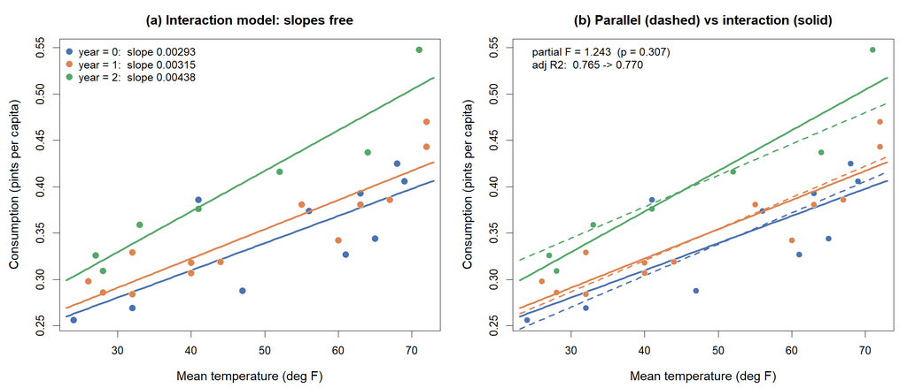

(a) The interaction model: three lines free to differ in slope. (b) The parallel-lines fit (dashed) drawn over the interaction fit (solid).

Parallel-lines model vs interaction model on the ice cream data.

| Criterion | 평행선 모형 | 상호작용 모형 | 판정 |
| --- | --- | --- | --- |
| 계수 개수 | 4 | 6 |  |
| $R^2$ | 0.7896 | 0.8093 | 항을 넣으면 항상 오름 |
| 수정 $R^2$ | 0.7653 | 0.7696 | 거의 그대로 |
| AIC | $\mathbf{-115.91}$ | $-114.87$ | 평행선 모형이 낫다 |
| Partial $F(2,\,24)$ |  | 1.243 ($p=0.307$) | 기울기 차이는 유의하지 않다 |

## 실무 적용: 원자로압력용기 조사취화 예측식

### ASTM E900-15

**Variables in the ASTM E900-15 embrittlement trend curve**

- 반응변수: 중성자 조사에 따른 샤르피 41 J 천이온도 변화량(transition temperature shift, TTS)
- 양적 설명변수: 구리, 니켈, 인, 망간 함량, 중성자 조사량(fluence)과 조사율(flux), 조사 온도
- **질적 설명변수: 제품 형태(용접재, 판재, 단조재)를 지시변수로 투입**
- 자료: 상용 원전 감시시험 1878건(13개국 감시시험 프로그램)
- 방법: 최대가능도로 26개 모수를 적합. 적합도 RMSE 13.3 °C, 결정계수 $R^2 = 0.875$
- 이 장의 코딩 규칙 그대로: 제품 형태가 $k$개 범주이면 지시변수는 $k-1$개, 나머지 한 범주는 기준
- 지시변수 계수는 조성과 조사 조건을 고정했을 때 제품 형태에 따른 TTS의 평균 차이로 해석

ASTM E900-21e1. / *Metals* 12(3), 481 (2022), doi:10.3390/met12030481.

## 이 장의 정리

### Dummy Variable

**한 줄 요약**: 범주 정보는 0/1 가변수 $k-1$개로 모형에 들어간다. 가변수는 절편을 바꾸고(평행선 모형), $x$와 곱해 넣으면 기울기까지 바꾼다(상호작용 모형).

- 질적 설명변수 $\rightarrow$ 가변수 $k-1$개 $\rightarrow$ 설계행렬 $\mathbf X$ 의 열. 회귀분석 8단계 중 4단계(모형 설정)의 확장
- 기준 범주는 절편 $\beta_0$ 가 담당. 가변수를 $k$개 모두 넣으면 완전 공선성으로 dummy trap
- 가변수 계수는 다른 설명변수를 고정했을 때의 조건부 기댓값 차이로 해석
- ice cream 자료: 온도를 고정해도 3년차는 1년차보다 평균 소비가 0.0743 높음

**다음 장**: Summary: 여덟 장을 관통한 공식과 기호를 한자리에 모으고, 현장에서 사용할 실무 체크리스트로 정리

## 참고문헌

### 이 장에서 인용한 문헌

- ASTM E900-21e1. *Standard Guide for Predicting Radiation-Induced Transition Temperature Shift in Reactor Vessel Materials*. ASTM International.
- *Metals*, 12(3), 481 (2022). doi:10.3390/met12030481
- Kutner, M. H., et al. (2005). *Applied Linear Statistical Models*, 5th ed. McGraw-Hill. (가변수 코딩)

### 교과서

- Kutner, M. H., Nachtsheim, C. J., Neter, J., & Li, W. (2005). *Applied Linear Statistical Models*, 5th ed. McGraw-Hill.
- Faraway, J. J. (2015). *Linear Models with R*, 2nd ed. CRC Press.